# Sensor Fault Detection Using Hierarchical Clustering

### Missing Values

```python
#Check for missing values
df.isnull().sum().sum()
```

```
0
```

```python
#Check for duplicated values
df.duplicated().sum()
```

```
0
```

### Data Visualization

To understand the nature of the data we need to visualize it. After visualization we observed that data has **4 distincted clusters** that can be seperated by distance based algorithms. Visuals also show as that since we compare different unit of measurements such as rotation per second, temperature, vibration etc. we need to normalize those measurements before we can compare them.

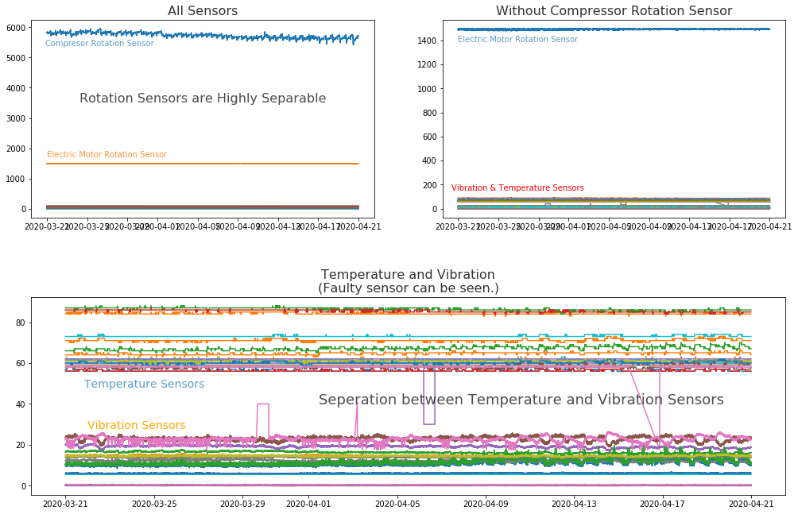

```python
#Create Figure
fig = plt.figure(figsize=(17,11))
#Create DataGrid
gs = gridspec.GridSpec(nrows=2,
                      ncols=2,
                      figure=fig,
                      width_ratios=[1,1],
                      height_ratios=[1,1],
                      wspace=0.2,
                      hspace=0.4)
#Set timestamp as index
df['Zaman'] = pd.to_datetime(df['Zaman'])
df_new = df.set_index('Zaman')

#number of rows to plot
n_rows = df.shape[0]

#Plot all sensors.
ax1 = fig.add_subplot(gs[0,0])
ax1.plot(df_new.iloc[:n_rows,:])
ax1.set_title('All Sensors', fontsize='16',alpha=0.8)
ax1.text(0.2, 0.88, 'Compresor Rotation Sensor',
         horizontalalignment='center',verticalalignment='center', transform=ax1.transAxes,
         color='#5e9dc9'
        )

ax1.text(0.22, 0.32, 'Electric Motor Rotation Sensor',
         horizontalalignment='center',verticalalignment='center', transform=ax1.transAxes,
        color='#ff9436')

ax1.text(0.5, 0.6, 'Rotation Sensors are Highly Separable',
         horizontalalignment='center',verticalalignment='center', transform=ax1.transAxes,
        fontsize='16', alpha=0.7)

#Plot sensors without Compressor Rotation
ax2 = fig.add_subplot(gs[0,1])

ax2.text(0.22, 0.9, 'Electric Motor Rotation Sensor',
         horizontalalignment='center',verticalalignment='center', transform=ax2.transAxes,
        color='#5e9dc9')

ax2.text(0.22, 0.15, 'Vibration & Temperature Sensors',
         horizontalalignment='center',verticalalignment='center', transform=ax2.transAxes,
        color='red')


ax2.plot(df_new.iloc[:n_rows,1:])
ax2.set_title('Without Compressor Rotation Sensor',fontsize='16',alpha=0.8)

#Temperature and vibration sensors
ax3 = fig.add_subplot(gs[1,:]);

ax3.text(0.15, 0.56, 'Temperature Sensors',
         horizontalalignment='center',verticalalignment='center', transform=ax3.transAxes,
        color='#5e9dc9', fontsize='14')

ax3.text(0.14, 0.35, 'Vibration Sensors',
         horizontalalignment='center',verticalalignment='center', transform=ax3.transAxes,
        color='orange', fontsize='14')

ax3.text(0.65, 0.48, 'Seperation between Temperature and Vibration Sensors',
         horizontalalignment='center',verticalalignment='center', transform=ax3.transAxes,
        fontsize='18', alpha=0.7)

ax3.plot(df_new.iloc[:n_rows,2:]);
ax3.set_title('Temperature and Vibration\n(Faulty sensor can be seen.)', fontsize='16',alpha=0.8);

del ax1
del ax2
del ax3
del fig
del gs
del n_rows
del df_new
```

```python
# As we can see in above chart. There has been 4 different cases which sensors starts to show faulty readings from field.
```

### Data Scaling

```python
#Sets Timestamp as Index,
#Normalize Data,
#Returns Normalized Data.
df_scaled = SFD.scalesData(df, is_normalize=True)
del df
```

```python
#Preview scaled data.
df_scaled.head(2)
```

|  | Timestamp | 177KI2030.PV | 177KI2025.PV | 177VI2041X.PV | 177TI2041A.PV | 177TI2041B.PV | 177TI2043A.PV | 177TI2045A.PV | 177TI2045B.PV | 177TI2048A.PV | ... | 177TI2040A.PV | 177TI2039A.PV | 177TI2039B.PV | 177VI2040Y.PV | 177VI2038Z.PV | 177VI2039Z.PV | 177VI2035.PV | 177VI2036.PV | 177VI2034X.PV | 177VI2033Y.PV |
| --- | --- | --- | --- | --- | --- | --- | --- | --- | --- | --- | --- | --- | --- | --- | --- | --- | --- | --- | --- | --- | --- |
| 0 | 2020-03-21 00:00:00 | 0.967559 | 0.247675 | 0.001612 | 0.013955 | 0.014454 | 0.014287 | 0.009968 | 0.009636 | 0.010134 | ... | 0.012128 | 0.009968 | 0.011795 | 0.001714 | 0.000004 | 0.000001 | 0.000071 | 0.000048 | 0.002295 | 0.002406 |
| 1 | 2020-03-21 00:01:00 | 0.967842 | 0.246561 | 0.001679 | 0.013959 | 0.014458 | 0.014292 | 0.009971 | 0.009639 | 0.010137 | ... | 0.012131 | 0.009971 | 0.011799 | 0.001672 | 0.000004 | 0.000001 | 0.000071 | 0.000048 | 0.002343 | 0.002402 |

2 rows × 42 columns

### Split and Transpose Data

Since we have 31 days of data we need to evenly split it to have dataframes that each of them represent one day.  
Also we splitted the data for every shift.  
Also we need to Transpose the data to cluster sensor not the operation state.

```python
#This function evenly splits given dataframe into 'n' number of dataframes and tranpose each dataframe.
df_list_daily = SFD.splitsTransposeData(df_scaled, n=number_of_days)
```

```python
#This function evenly splits given dataframe into 'n' number of dataframes and tranpose each dataframe.
df_list_8Hours = SFD.splitsTransposeData(df_scaled, n=number_of_days*3)
```

```python
#Complete 31 days of data. For dendrogram visuals
df_T = SFD.splitsTransposeData(df_scaled, n=1)
```

```python
print('"df_list_daily" contains {} dataframes each one of them represent one day.'.format(len(df_list_daily)))
```

```
"df_list_daily" contains 31 dataframes each one of them represent one day.
```

```python
print('"df_list_8Hours" contains {} dataframes each one of them represent 8 hours (one shift).'.format(len(df_list_8Hours)))
```

```
"df_list_8Hours" contains 93 dataframes each one of them represent 8 hours (one shift).
```

### Outlier Detection using DBSCAN

```python
#Filters data using DBSCAN. Look SFD_utils.py for details.
for df in df_list_daily:
    SFD.filterDBSCAN(df)
```

```
0 rows clustered as noise.
0 rows clustered as noise.
0 rows clustered as noise.
0 rows clustered as noise.
0 rows clustered as noise.
0 rows clustered as noise.
0 rows clustered as noise.
0 rows clustered as noise.
0 rows clustered as noise.
0 rows clustered as noise.
0 rows clustered as noise.
0 rows clustered as noise.
0 rows clustered as noise.
0 rows clustered as noise.
0 rows clustered as noise.
```

[output cut: 16 more lines]

```python
for df in df_list_8Hours:
    SFD.filterDBSCAN(df)
```

```
0 rows clustered as noise.
0 rows clustered as noise.
0 rows clustered as noise.
0 rows clustered as noise.
0 rows clustered as noise.
0 rows clustered as noise.
0 rows clustered as noise.
0 rows clustered as noise.
0 rows clustered as noise.
0 rows clustered as noise.
0 rows clustered as noise.
0 rows clustered as noise.
0 rows clustered as noise.
0 rows clustered as noise.
0 rows clustered as noise.
```

[output cut: 78 more lines]

## Analysis

### Finding the Right Linkage Method

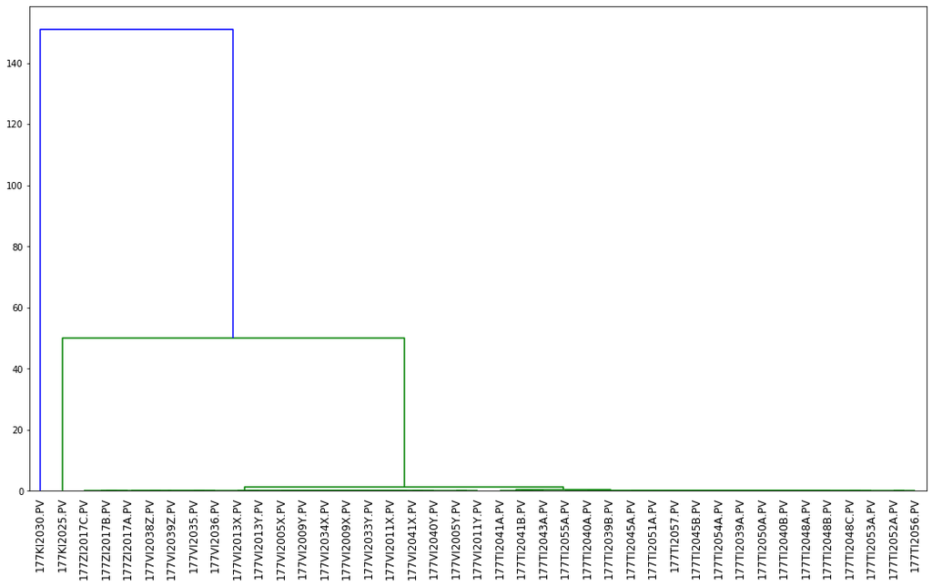

```python
#Dendrogram for 30 days of data
SFD.plotSimpleDendogram(df_T[0][:],'single')
```

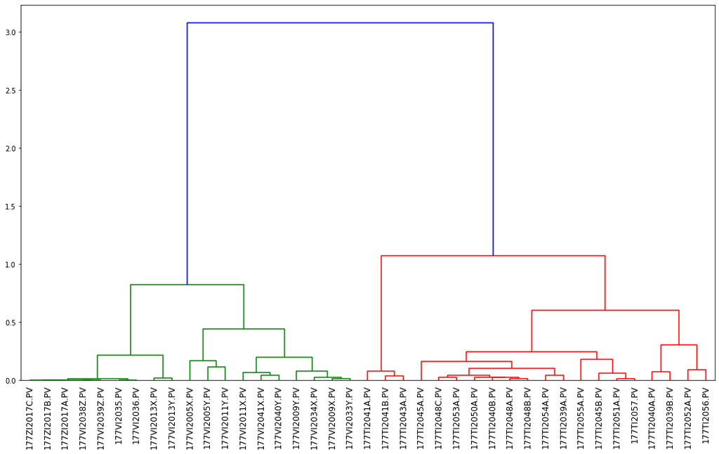

```python
#Dendrogram for 30 days of data without rotation sensors, visual purposes
SFD.plotSimpleDendogram(df_T[0][2:],'complete')
#Temperature and vibration sensors are seperated perfectly.
```

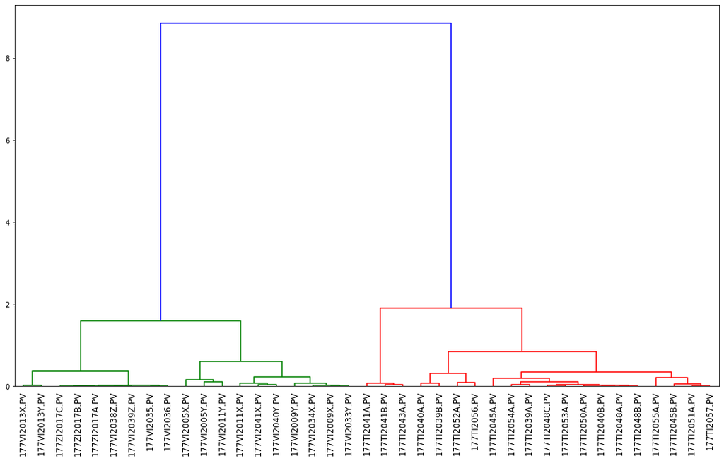

```python
#Dendrogram for 30 days of data without rotation sensors, visual purposes
SFD.plotSimpleDendogram(df_T[0][2:],'ward')
#Temperature and vibration sensors are seperated perfectly.
```

```python
#This function returns average silhouette score for given dataframe list.
def return_average_silhouette_score(clust, df_list):
    list_of_scores = []
    for df in df_list:
        labels = clust.fit_predict(df)
        score = metrics.silhouette_score(df, labels)
        list_of_scores.append(score)

    return sum(list_of_scores)/len(list_of_scores)
```

```python
#instantiate HC clusters
clust_single = cluster.AgglomerativeClustering(n_clusters=4, linkage='single')
clust_ward = cluster.AgglomerativeClustering(n_clusters=4, linkage='ward')
clust_average = cluster.AgglomerativeClustering(n_clusters=4, linkage='average')
clust_complete = cluster.AgglomerativeClustering(n_clusters=4, linkage='complete')
```

```python
#Loop thru all in df_list_8hours to calculate silhouette coef. to compare which linkage method is better.
score_single = return_average_silhouette_score(clust_single, df_list_8Hours)
score_ward = return_average_silhouette_score(clust_ward, df_list_8Hours)
score_average = return_average_silhouette_score(clust_average, df_list_8Hours)
score_complete = return_average_silhouette_score(clust_single, df_list_8Hours)

print("Silhouette Coef for Single: {}\nSilhouette Coef for Ward: {}\nSilhouette Coef for Average: {}\n\
Silhouette Coef for Complete: {}\n".format(score_single,score_ward,score_average,score_complete))
```

```
Silhouette Coef for Single: 0.7844128996583485
Silhouette Coef for Ward: 0.7844128996583485
Silhouette Coef for Average: 0.7844434582444041
Silhouette Coef for Complete: 0.7844128996583485
```

#### Compare Different Linkages

We use plotDendogramLineCharts function to visually see dendogram and raw data side by side.

##### WARD

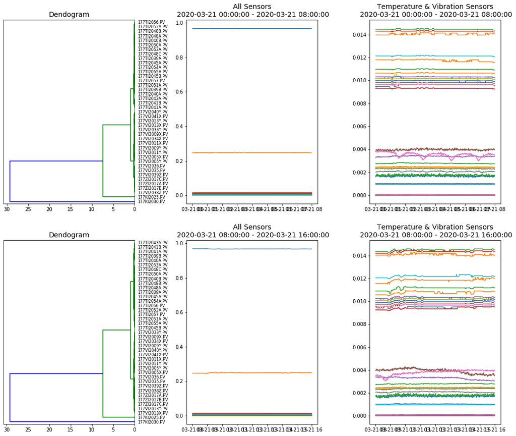

```python
#Plots dendogram and line chart for each day.
#By giving n_rows equal to 2 we only see first 2 days.
#By changing linkage type we can visually see with linkage calculation works for us.

#WARD
SFD.plotDendogramsLineCharts(df_list=df_list_8Hours, n_rows=2, n_cols=3,figsize=(18,15),linkage='ward')
```

##### AVERAGE

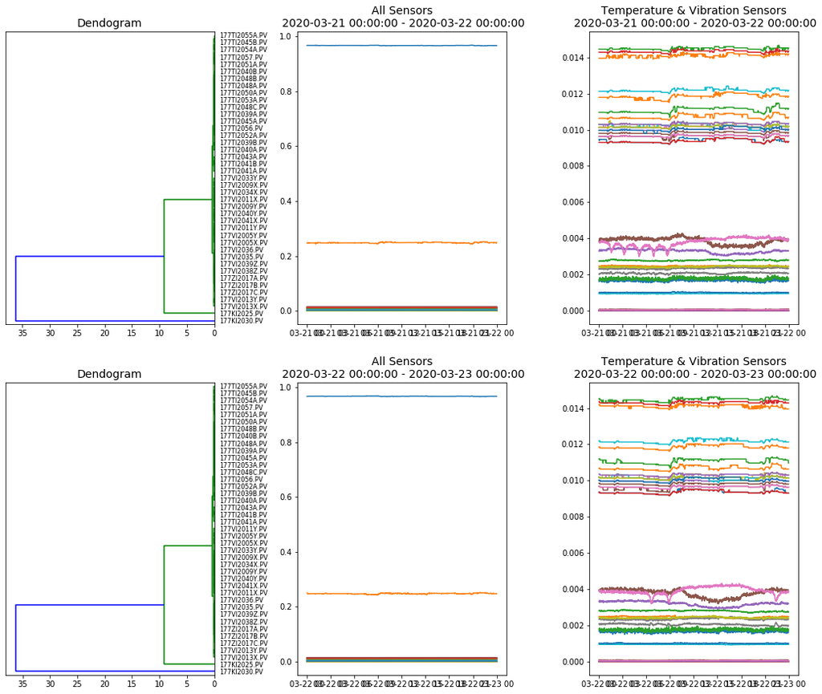

```python
#AVERAGE
SFD.plotDendogramsLineCharts(df_list=df_list_daily, n_rows=2, n_cols=3,figsize=(18,15),linkage='average')
```

##### COMPLETE

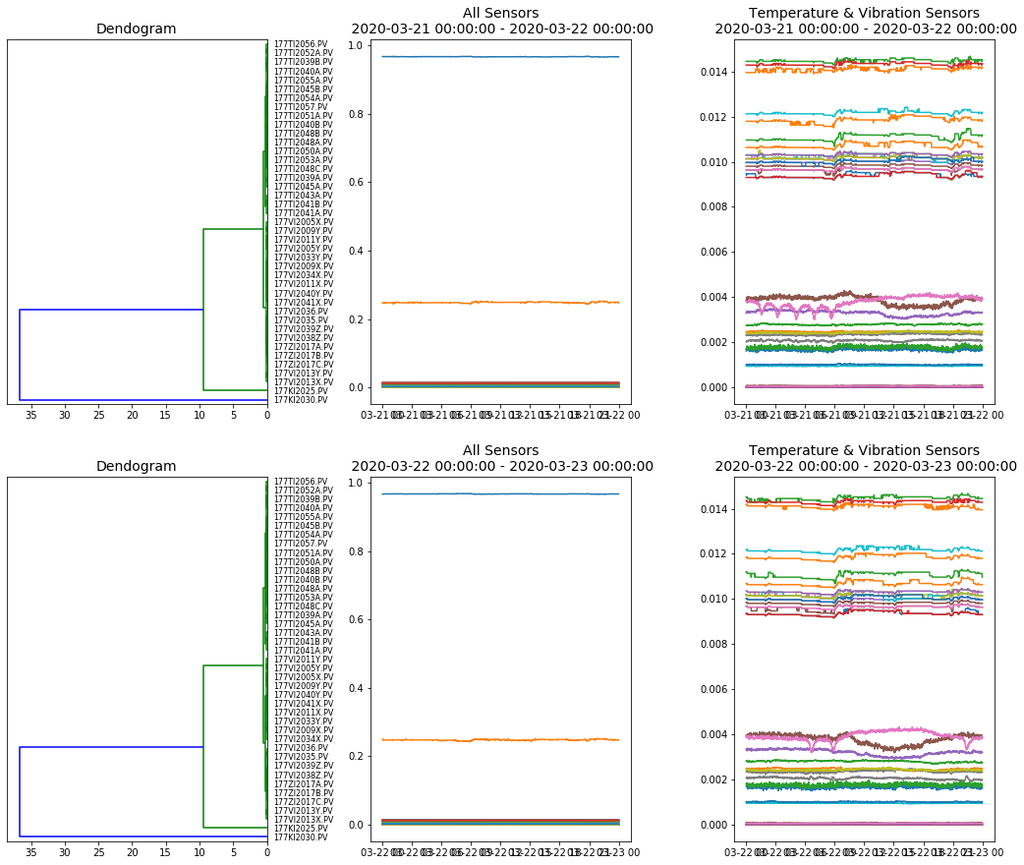

```python
#COMPLETE

SFD.plotDendogramsLineCharts(df_list=df_list_daily, n_rows=2, n_cols=3,figsize=(18,15),linkage='complete')
```

##### SINGLE

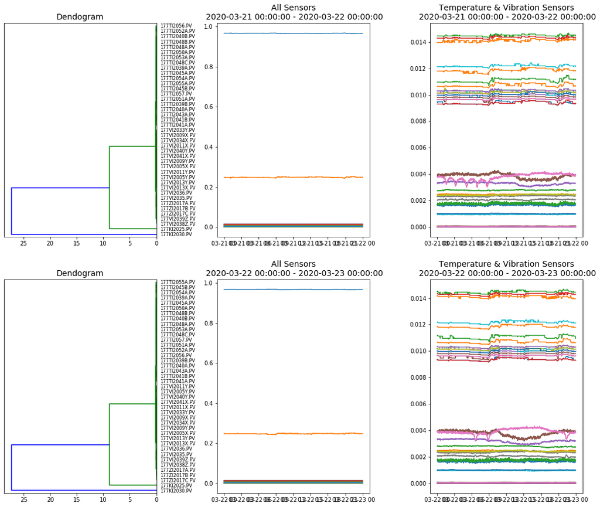

```python
#SINGLE

SFD.plotDendogramsLineCharts(df_list=df_list_daily, n_rows=2, n_cols=3,figsize=(18,15),linkage='single')
```

## MODELLING & TESTING/Validation

To validate our model we need check historic data to find faults visually and compare it with what our algorthim findings. So in **1.3 Data Visualization** part we can clearly see that there are 4 distinct faults in various sensors. We should be able to find those faults with our algorithm.

### Modelling

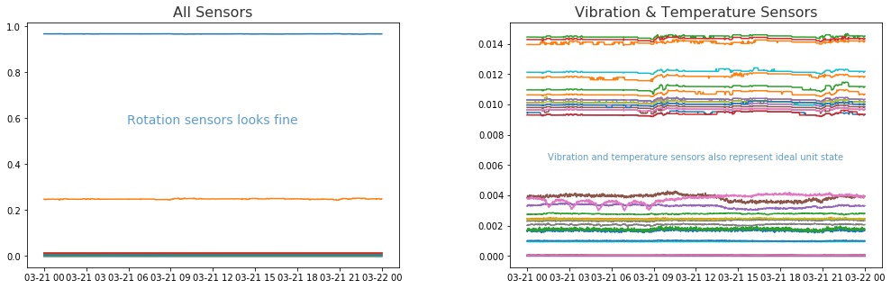

```python
#Now we have df_list_daily that is contains daily data.
#We need to select one of these days as "finger-print" that represents normal operation of the unit.
#Lets use some visual to support or judgement..
#Lets take look at first df in df_list_daily
finger_print_df =df_list_daily[0]
#To plot that we need to transpose it
finger_print_df_T = np.transpose(finger_print_df)

#Now we can plot it
#Create Figure
fig = plt.figure(figsize=(17,5))
#Create DataGrid
gs = gridspec.GridSpec(nrows=1,
                      ncols=2,
                      figure=fig,
                      width_ratios=[1,1],
                      height_ratios=[1],
                      wspace=0.3,
                      hspace=0.2)

#Plot all sensors.
ax1 = fig.add_subplot(gs[0,0])
ax1.plot(finger_print_df_T);
ax1.set_title('All Sensors', fontsize='16',alpha=0.8)
ax1.text(0.5, 0.6, 'Rotation sensors looks fine',
         horizontalalignment='center',verticalalignment='center', transform=ax1.transAxes,
         color='#5e9dc9', fontsize='14'
        )

#Plot vibrations & temperatures.
ax2 = fig.add_subplot(gs[0,1])
ax2.plot(finger_print_df_T.iloc[:,2:]);
ax2.set_title('Vibration & Temperature Sensors', fontsize='16',alpha=0.8)
ax2.text(0.5, 0.45, 'Vibration and temperature sensors also represent ideal unit state',
         horizontalalignment='center',verticalalignment='center', transform=ax2.transAxes,
         color='#5e9dc9', fontsize='10'
        );
```

**Result from visuals**  
After looking at the data we can easly use first data dataframe in "df_list_daily" as finger-print of the unit.

### Testing / Validation

```python
#instantiate WARD HC
clust = cluster.AgglomerativeClustering(n_clusters=4, linkage='ward')
```

```python
#Cluster finger-print
finger_print=SFD.returnSensorClusters(df=finger_print_df,clust=clust)
```

We loop thru "df_list_8Hours" and clustered each 8 hour of data to compare it with "finger_print" to find faults seen in **1.3 Data Visualization**.

```
Faulty sensors detected = ['177VI2011Y.PV']
```

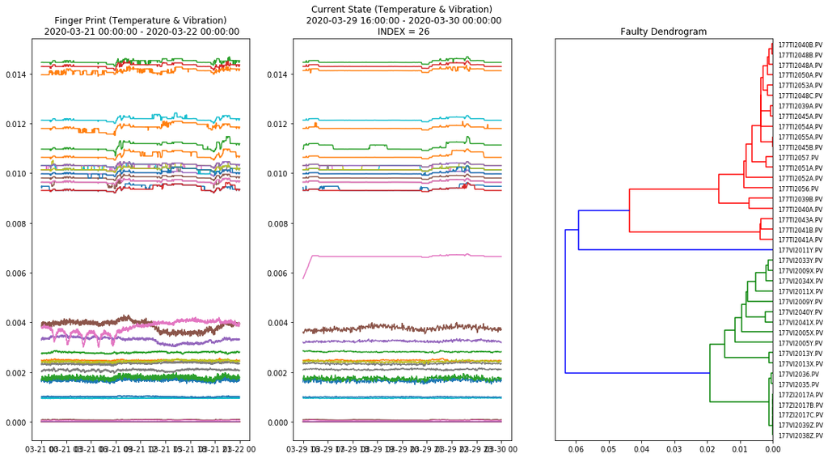

```
Faulty sensors detected = ['177TI2045A.PV']
```

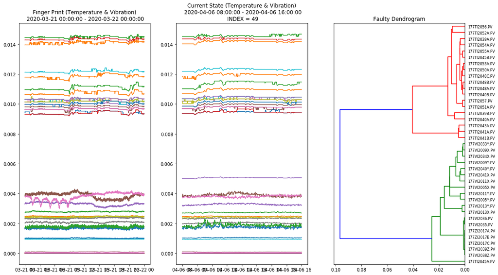

```
Faulty sensors detected = ['177TI2055A.PV']
```

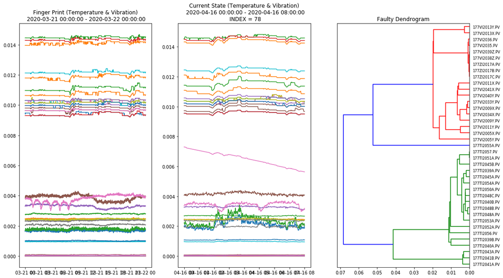

```
Faulty sensors detected = ['177TI2055A.PV']
```

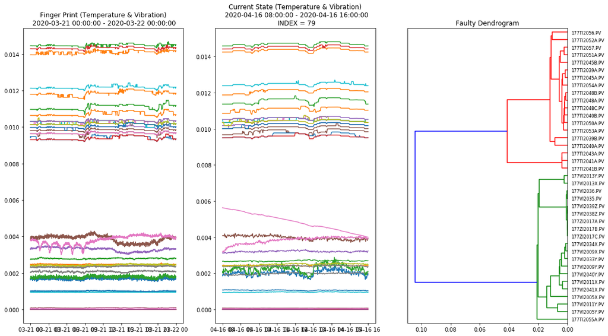

```
Faulty sensors detected = ['177TI2055A.PV']
```

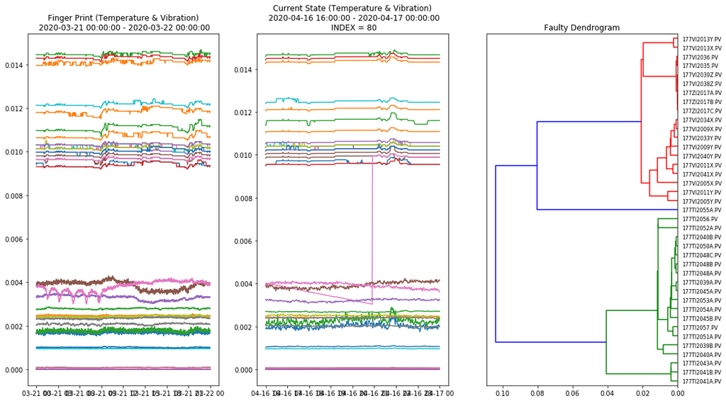

```python
#healtCheck function loops thru given "list_of_dfs", clusters each dataframe and
#compares those cluster with given finger_print
#Given finger_print_df is for visual purposes.
#For more information about the function check out the doc_string.
SFD.healthCheck(list_of_dfs=df_list_8Hours, finger_print=finger_print, finger_print_df=finger_print_df, clust=clust)
```

#### Conclusion on Testing

As we can see in above visuals, our algorithm detects 3 out 4 faults in our dataset and returns fault sensors with their names. It is very good start for our production units because there is no fault detection system installed before this one.

## The Application

```python
import mb_ThdData as thd #This is a library that I build for fetching data from our company database. So I share the code with you,
#but since you are outside of our company network it won't work for you. Sorry..
```

```python
#Fetchs daily data when it called.
#We'll use one minute average data.
#tag_list is excel file that contains sensor tags.
#number_of_days defines start date for data retrevial process. End date is present date.
#Start date  = (End Date) - (number_of_days)

#Fetches 24hours of data when its calld
fetcher_24hours = thd.ThdData(aggregateType='OPC_Time_Average'
                      ,interval='1min'
                      ,file_name='177K201_sensorNameList'
                      ,number_of_days=1)

#Fetches 8hours of data when its called
fetcher_8hours = thd.ThdData(aggregateType='OPC_Time_Average'
                      ,interval='1min'
                      ,file_name='177K201_sensorNameList'
                      ,number_of_days=1/3)
```

```python
def main_app():
    #there are 3 shifts in one unit shift_counter represents that
    shift_counter=0
    #is firts shift same as finger print
    is_first_ok=False
    #is second shift same as finger print
    is_second_ok=False
    #is third shift same as finger print
    is_third_ok=False

    while True:
        now = date.today()
        print('FETCHING DAILY DATA.. {}'.format(now))
        #Get daily data
        df_day = fetcher_24hours.download()
        #Preprocess
        #Returns Normalized Data.
        df_scaled = SFD.scalesData(df_day, is_normalize=True)

        #Transpose (We need to split the data so n=1)
        df_T = SFD.splitsTransposeData(df_scaled, n=1)[0]

        #Noise filtering DBSCAN
        df_f_T = SFD.filterDBSCAN(df_T)

        #instantiate Agglomerative Hierarchical Clustring instance
        clust = cluster.AgglomerativeClustering(n_clusters=4, linkage='complete')

        #Get fingerprint
        finger_print_df = df_f_T
        finger_print = SFD.returnSensorClusters(df=finger_print_df,clust=clust)

        while True:
            if (shift_counter == 0 or 1 or 2):
                #Wait for 8 hours after that get new data and compare it with finger print
                time.sleep(60*60*8) #8hours
                #Get system date
                now_shift = datetime.now()
                #Format datetime
                dt_shift = now_shift.strftime("%d/%m/%Y %H:%M:%S")

                print('{} FETCHING SHIFT DATA.. {}'.format((shift_counter + 1), dt_shift))

                #Get data, normalize it, and transpose
                shift_df = SFD.splitsTransposeData(SFD.scalesData(fetcher_8hours.download(),is_normalize=True), n=1)[0]

                #Noise filter DBSCAN
                shift_df_f = SFD.filterDBSCAN(shift_df)

                #Get clusters for that shift
                shift_state = SFD.returnSensorClusters(df=shift_df_f,clust=clust)

                #Check wheter or not finger print and shift state are the same
                if ((finger_print.equals(shift_state))):
                    if (shift_counter == 0):
                        print("first shift is ok")
                        is_first_ok = True
                        #shift is complete add one more
                        shift_counter += 1
                    elif (shift_counter == 1):
                        print("second shift is ok")
                        is_second_ok = True
                        #shift is complete add one more
                        shift_counter += 1
                    elif (shift_counter == 2):
                        print("third shift is ok")
                        is_third_ok = True
                        #shift is complete add one more
                        shift_counter += 1
                else:
                    #print faulty sensors.
                    print("FAULT DETECTED.\nFAULTY SENSORS = {}".format(SFD.returnDifferentClusteredTags(finger_print,
                                                                                                     shift_state)))

                    #plot for compare two dataframe
                    SFD.plotComparisionPlot2(finger_print_df, shift_df)

                    #Dont break the loop and change the finger_print.
                    #Because there is something wrong in the unit
                    #Dont update finger-print until unit comes back to normal.
                    is_first_ok = False
                    is_second_ok = False
                    is_third_ok = False
                    shift_counter = 0


                #If all 3 shift (1 day) is complete and if we dont detect fault we should use these new 24 hours data to
                #produce new finger print and repeat the same producure.
                if ((shift_counter == 3) and (is_first_ok==True) and (is_second_ok==True) and (is_third_ok==True)):
                    #ALL OK, Reset everthing.
                    print('All OK. Updating Finger-Print..')
                    shift_counter = 0
                    is_first_ok = False
                    is_second_ok = False
                    is_third_ok = False
                    break
```

Normaly program runs every 8 hours but for demo purposes, it runs every minute.

```python
main_app()
```

```
FETCHING DAILY DATA.. 2020-04-28
0 rows clustered as noise.
1 FETCHING SHIFT DATA.. 28/04/2020 22:49:14
0 rows clustered as noise.
first shift is ok
2 FETCHING SHIFT DATA.. 28/04/2020 22:50:22
0 rows clustered as noise.
second shift is ok
3 FETCHING SHIFT DATA.. 28/04/2020 22:51:30
0 rows clustered as noise.
third shift is ok
All OK. Updating Finger-Print..
FETCHING DAILY DATA.. 2020-04-28
0 rows clustered as noise.
1 FETCHING SHIFT DATA.. 28/04/2020 22:52:51
0 rows clustered as noise.
first shift is ok
2 FETCHING SHIFT DATA.. 28/04/2020 22:53:59
0 rows clustered as noise.
second shift is ok
3 FETCHING SHIFT DATA.. 28/04/2020 22:55:07
0 rows clustered as noise.
third shift is ok
All OK. Updating Finger-Print..
FETCHING DAILY DATA.. 2020-04-28
0 rows clustered as noise.
```

[output not shown]

## Further Improvements

### Additional solutions

To improve existing solution and detect all faults another clustering algorithm might be used to cooperate with existing solution. For example DBSCAN might be good chooice to detect short lived faults.

### Improvements for current solution

Another improvement can be made on top of existing solution might be predicting sensor readings while they are faulty.</br> For that reason neural networks solutions can be used.